```python
### Imports required for the project ###

import os
import pathlib
import csv
import matplotlib.pyplot as plt
import numpy as np
import pandas as pd
from IPython.display import Image

import tensorflow as tf
from tensorflow.keras.callbacks import ModelCheckpoint

from keras.models import load_model
from keras.utils import image_dataset_from_directory
from keras.models import Sequential
from keras.layers import (Conv2D,
                          MaxPooling2D,
                          Rescaling,
                          Activation,
                          Dropout,
                          Flatten,
                          Dense)
```

# Problem and Data

```
This notebook is an attempt at training a neural network to classify images of human cell samples as either cancerous or not. The data comes from Kaggle which hosted it as part of a competition to build a predictive model

Data Source: https://www.kaggle.com/c/histopathologic-cancer-detection/data

The images were supplied as .tiff images 96 x 96 pixels in 3 layers to account for color. There are 220,025 training images which are preclassified (0 non-cancerous, 1 cancerous) according to an accompanying csv file with labels. There are 57,458 images in the test folder which do not have labels and instead require a submission to kaggle in order to validate.
```

# Data Cleaning

```
Data cleaning in this project consisted primarily of reformatting the data and data storage into a format that keras was more familiar with.
```

#### Format of images

```
The Keras method, image_dataset_from_directory, does not accept .tiff files so Pillow python module was used to convert all of the files from .tiff to .bmp. Bmp was chosen because it does not lose any of the resolution from the images and is compatible with keras.
```

#### Data storage

```
Keras expects the data to be stored in separate folders, each folder name matching the label of the data. Supposedly keras can be fed the labels as a list, but after many hours I was unable to discover the correct way to do this so it was easier to use a one time script to read the labels csv file and move the images into separate folders based on their labels.
```

# Setup variables

```python
img_width, img_height = 96, 96
data_dir = pathlib.Path(os.path.abspath('data/train'))
labels_data = 'data/train_labels.csv'
nb_train_samples = len(os.listdir(data_dir))
epochs = 20
batch_size = 32
```

# Load Data into notebook

```python
train_ds, valid_ds = image_dataset_from_directory(
  data_dir,
  validation_split=0.2,
  subset="both",
  seed=123,
  image_size=(img_height, img_width),
  batch_size=batch_size)
```

```
Found 220025 files belonging to 2 classes.
Using 176020 files for training.
Using 44005 files for validation.
```

[output not shown]

```python
class_names = train_ds.class_names
num_classes = len(class_names)
print(class_names)
```

```
['0', '1']
```

```python
train_ds_fetched = train_ds.cache().shuffle(1000).prefetch(buffer_size=tf.data.AUTOTUNE)
valid_ds_fetched = valid_ds.cache().prefetch(buffer_size=tf.data.AUTOTUNE)
```

# Sample Images

[output not shown]

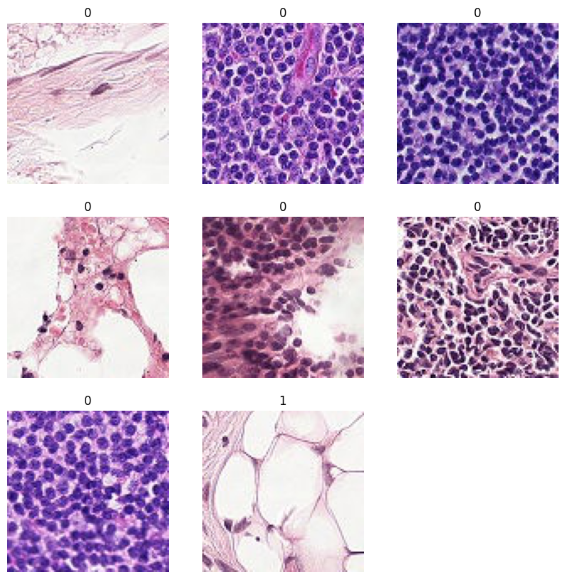

```python
plt.figure(figsize=(10, 10))
for images, labels in train_ds_fetched.take(1):
    for i in range(8):
      ax = plt.subplot(3, 3, i + 1)
      plt.imshow(images[i].numpy().astype("uint8"))
      plt.title(class_names[int(labels[i])])
      plt.axis("off")
```

# Building the model

For simplicity I chose a Sequential model with 10 layers.

#### 1. The Rescaling layer normalizes the RGB values into 0-1 range which helps with convergence during training.

#### 2. The Conv2D is a convolutional layer with 16 filters. This is an attempt to find some of the smaller patterns and features in the images. There is padding to prevent any downscaling of the image at this stage.

#### 3. MaxPooling2D layer explicitly down samples the input to reduce the size of the image for later layers to process.

#### 4. and 5. Another set of layers of convolution and max pooling. These layers pull out some of the larger features and further reduce the size for the last layer. There are 32 filters in this Conv layer.

#### 6. and 7. A final set of filters to learn the more complex features of the images. There are 64 filters in this layer.

#### 8. Flatten reduces the output from the last layer into a 1D vector which can be fed into the Dense, fully connected layer.

#### 9. Dense has 128 neurons which are all fully connected to the output from the Flatten layer and the final Dense layer. This layer helps pull out some of the non-linear connections between the features.

#### 10. Dense final layer outputs probabilites for each of the two data classes and serves as the final arbiter of the classification.

```python
model = Sequential([
  Rescaling(1./255, input_shape=(img_height, img_width, 3)),
  Conv2D(16, 3, padding='same', activation='relu'),
  MaxPooling2D(),
  Conv2D(32, 3, padding='same', activation='relu'),
  MaxPooling2D(),
  Conv2D(64, 3, padding='same', activation='relu'),
  MaxPooling2D(),
  Flatten(),
  Dense(128, activation='relu'),
  Dense(num_classes)
])
```

```python
model.compile(optimizer='adam',
              loss=tf.keras.losses.SparseCategoricalCrossentropy(from_logits=True),
              metrics=['accuracy'])
```

```python
model.summary()
```

```
Model: "sequential"
_________________________________________________________________
 Layer (type)                Output Shape              Param #
=================================================================
 rescaling (Rescaling)       (None, 96, 96, 3)         0

 conv2d (Conv2D)             (None, 96, 96, 16)        448

 max_pooling2d (MaxPooling2  (None, 48, 48, 16)        0
 D)

 conv2d_1 (Conv2D)           (None, 48, 48, 32)        4640

 max_pooling2d_1 (MaxPoolin  (None, 24, 24, 32)        0
 g2D)

 conv2d_2 (Conv2D)           (None, 24, 24, 64)        18496

 max_pooling2d_2 (MaxPoolin  (None, 12, 12, 64)        0
 g2D)

 flatten (Flatten)           (None, 9216)              0

 dense (Dense)               (None, 128)               1179776

 dense_1 (Dense)             (None, 2)                 258

=================================================================
Total params: 1203618 (4.59 MB)
Trainable params: 1203618 (4.59 MB)
Non-trainable params: 0 (0.00 Byte)
_________________________________________________________________
```

# Setup training environment

Store Checkpoints to allow breaking up of the training as time allows

```python
checkpoint_dir = './checkpoints_01'
checkpoint_filepath = os.path.join(checkpoint_dir, 'weights-{epoch:02d}-{val_loss:.2f}.hdf5')
checkpoint_callback = ModelCheckpoint(
    filepath=checkpoint_filepath,
    monitor='val_loss',
    verbose=1,
    save_best_only=True,
    mode='min'
)
```

```python
# Run this cell when resuming from a specific checkpoint
#model = load_model('./checkpoints/weights-05-0.24.hdf5')
```

### Software environment

Initial training showed that a task this large, training on 220,000 images through a large neural network demonstrated that the CPU on this laptop was not up to the task to complete the training in under 8 hours per run.

In order to utilize the GPU, I set up a tensoflow environment. The newer tensor flow versions no longer support GPU usage on native Windows so I created a WSL conda environment running this notebook with linux.

Utilizing the GPU reduced the runtime from over 10 minutes per epoch to under 3 minutes each with an average close to 2 minutes.

# Train model

```python
history = model.fit(
  train_ds_fetched,
  validation_data=valid_ds_fetched,
  epochs=epochs,
  batch_size=batch_size,
  callbacks=[checkpoint_callback],
)
```

[output not shown]

```
Epoch 1: val_loss improved from inf to 0.32943, saving model to ./checkpoints_01/weights-01-0.33.hdf5
```

```
Epoch 2: val_loss improved from 0.32943 to 0.31600, saving model to ./checkpoints_01/weights-02-0.32.hdf5
Epoch 3: val_loss improved from 0.31600 to 0.25774, saving model to ./checkpoints_01/weights-03-0.26.hdf5
Epoch 4: val_loss improved from 0.25774 to 0.24533, saving model to ./checkpoints_01/weights-04-0.25.hdf5
Epoch 5: val_loss improved from 0.24533 to 0.23636, saving model to ./checkpoints_01/weights-05-0.24.hdf5
Epoch 6: val_loss did not improve from 0.23636
Epoch 7: val_loss did not improve from 0.23636
Epoch 8: val_loss did not improve from 0.23636
Epoch 9: val_loss did not improve from 0.23636
Epoch 10: val_loss did not improve from 0.23636
Epoch 11: val_loss did not improve from 0.23636
Epoch 12: val_loss did not improve from 0.23636
Epoch 13: val_loss did not improve from 0.23636
Epoch 14: val_loss did not improve from 0.23636
Epoch 15: val_loss did not improve from 0.23636
Epoch 16: val_loss did not improve from 0.23636
Epoch 17: val_loss did not improve from 0.23636
Epoch 18: val_loss did not improve from 0.23636
Epoch 19: val_loss did not improve from 0.23636
Epoch 20: val_loss did not improve from 0.23636
```

# Visualize the results of the training run

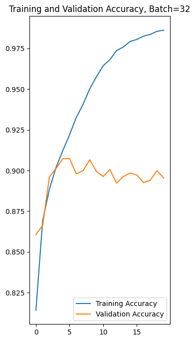

```python
acc = history.history['accuracy']
val_acc = history.history['val_accuracy']

loss = history.history['loss']
val_loss = history.history['val_loss']

epochs_range = range(epochs)

plt.figure(figsize=(8, 8))
plt.subplot(1, 2, 1)
plt.plot(epochs_range, acc, label='Training Accuracy')
plt.plot(epochs_range, val_acc, label='Validation Accuracy')
plt.legend(loc='lower right')
plt.title('Training and Validation Accuracy, Batch=32')
```

# Refactor the training model

```python
model = Sequential([
  Rescaling(1./255, input_shape=(img_height, img_width, 3)),
  Conv2D(16, 3, padding='same', activation='relu'),
  MaxPooling2D(),
  Dropout(rate=0.25),
  Conv2D(32, 3, padding='same', activation='relu'),
  MaxPooling2D(),
  Dropout(rate=0.25),
  Conv2D(64, 3, padding='same', activation='relu'),
  MaxPooling2D(),
  Flatten(),
  Dense(128, activation='relu'),
  Dropout(rate=0.25),
  Dense(num_classes)
])
```

```python
model.compile(optimizer='adam',
              loss=tf.keras.losses.SparseCategoricalCrossentropy(from_logits=True),
              metrics=['accuracy'])
```

# Retrain the model

```python
checkpoint_dir = './checkpoints_02'
checkpoint_filepath = os.path.join(checkpoint_dir, 'weights-{epoch:02d}-{val_loss:.2f}.hdf5')
checkpoint_callback = ModelCheckpoint(
    filepath=checkpoint_filepath,
    monitor='val_loss',
    verbose=1,
    save_best_only=True,
    mode='min'
)
```

```python
history = model.fit(
  train_ds_fetched,
  validation_data=valid_ds_fetched,
  epochs=epochs,
  batch_size=batch_size,
  callbacks=[checkpoint_callback],
)
```

```
2024-02-14 11:40:27.003898: E tensorflow/core/grappler/optimizers/meta_optimizer.cc:961] layout failed: INVALID_ARGUMENT: Size of values 0 does not match size of permutation 4 @ fanin shape insequential_1/dropout/dropout/SelectV2-2-TransposeNHWCToNCHW-LayoutOptimizer
```

```
Epoch 1: val_loss improved from inf to 0.44145, saving model to ./checkpoints_02/weights-01-0.44.hdf5
Epoch 2: val_loss did not improve from 0.44145
Epoch 3: val_loss improved from 0.44145 to 0.35018, saving model to ./checkpoints_02/weights-03-0.35.hdf5
Epoch 4: val_loss did not improve from 0.35018
Epoch 5: val_loss improved from 0.35018 to 0.34347, saving model to ./checkpoints_02/weights-05-0.34.hdf5
Epoch 6: val_loss improved from 0.34347 to 0.24495, saving model to ./checkpoints_02/weights-06-0.24.hdf5
Epoch 7: val_loss did not improve from 0.24495
Epoch 8: val_loss did not improve from 0.24495
Epoch 9: val_loss improved from 0.24495 to 0.23984, saving model to ./checkpoints_02/weights-09-0.24.hdf5
Epoch 10: val_loss improved from 0.23984 to 0.23545, saving model to ./checkpoints_02/weights-10-0.24.hdf5
Epoch 11: val_loss improved from 0.23545 to 0.22472, saving model to ./checkpoints_02/weights-11-0.22.hdf5
Epoch 12: val_loss improved from 0.22472 to 0.22008, saving model to ./checkpoints_02/weights-12-0.22.hdf5
Epoch 13: val_loss did not improve from 0.22008
Epoch 14: val_loss did not improve from 0.22008
Epoch 15: val_loss did not improve from 0.22008
Epoch 16: val_loss did not improve from 0.22008
Epoch 17: val_loss improved from 0.22008 to 0.21844, saving model to ./checkpoints_02/weights-17-0.22.hdf5
Epoch 18: val_loss did not improve from 0.21844
Epoch 19: val_loss did not improve from 0.21844
Epoch 20: val_loss did not improve from 0.21844
```

# Visualize the results of the training run

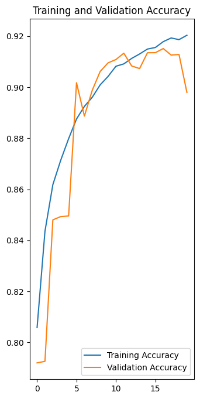

```python
acc = history.history['accuracy']
val_acc = history.history['val_accuracy']

loss = history.history['loss']
val_loss = history.history['val_loss']

epochs_range = range(epochs)

plt.figure(figsize=(8, 8))
plt.subplot(1, 2, 1)
plt.plot(epochs_range, acc, label='Training Accuracy')
plt.plot(epochs_range, val_acc, label='Validation Accuracy')
plt.legend(loc='lower right')
plt.title('Training and Validation Accuracy')
```

# Generate the test predictions

```python
test_dir = pathlib.Path(os.path.abspath('data/test'))
test_ds = image_dataset_from_directory(
  test_dir,
  seed=123,
  image_size=(img_height, img_width),
  label_mode=None,
  shuffle=False)
```

```
Found 57458 files belonging to 1 classes.
```

#### Choosing the final model

Both check points 12 and 17 performed relatviely the same as far as validation loss was concerned and I was curious if it would be better to use the earlier model in case there was overfitting coming from the extra 5 epochs run. I decided to submit both to kaggle in an effort to determine the best model.

```python
# Load the best model from the checkpoints
model = load_model('./checkpoints_02/weights-12-0.22.hdf5')
```

```python
# Make predictions using the trained model
test_steps = np.ceil(len(test_ds) / batch_size)
predictions = model.predict(test_ds)

# Get the class labels
predicted_classes = np.argmax(predictions, axis=1)

# Save the predictions to a CSV file
filenames = test_ds.file_paths

results = pd.DataFrame({'filepaths': filenames, 'label': predicted_classes})
results['id'] = results['filepaths'].apply(lambda x: os.path.splitext(os.path.basename(x))[0])
results = results[['id','label']]
results.to_csv('test_predictions.csv', index=False)
```

### Kaggle Submission from Checkpoint 12

[figure not shown]

```python
Image(filename='ckpt 12.png')
```

#### Reload from checkpoint 17

```python
# Load the best model from the checkpoints
model = load_model('./checkpoints_02/weights-17-0.22.hdf5')
```

```python
# Make predictions using the trained model
test_steps = np.ceil(len(test_ds) / batch_size)
predictions = model.predict(test_ds)

# Get the class labels
predicted_classes = np.argmax(predictions, axis=1)

# Save the predictions to a CSV file
filenames = test_ds.file_paths

results = pd.DataFrame({'filepaths': filenames, 'label': predicted_classes})
results['id'] = results['filepaths'].apply(lambda x: os.path.splitext(os.path.basename(x))[0])
results = results[['id','label']]
results.to_csv('test_predictions.csv', index=False)
```

### Kaggle Submission from Checkpoint 17

[figure not shown]

```python
Image(filename='17.png')
```

# Conclusions

Overall I think it was an interesting exercise. I certainly struggled with getting my computer to run such a large scale model far more than I did creating and running the model itself. One of the frustrating things in Data Science is how fast everything moves along so any online tutorial or example code is already using deprecated methods by the time it is published. The model itself could probably do a lot better than 87% accuracy given time to dive into other layers or more complicated structures. One thing I would like to try is find a way to generate images from the intermediate steps to see what the model might be pulling out of the images at each layer.

I was encouraged that the dropout layer did seem to help a bit with overfitting and that it really slowed down the learning rate. Prior to the dropout layers, the validation loss peaked fast at epoch 5 and then didn't improve.

One other thing I would be curious to try as researcher is to see how consistent the predictions are on a per patient basis, vs per sample. If we could know that some set of samples came from patients who were positive for cancer, but not all the images were of the cancer, would the model be able to correctly predict enough of the positive images that this kind of analysis became overwhelming? For example, maybe a single image prediction is only accurate to 95% but a group of images from the same patient would boost the accuracy to 99.9% based on the summation of the individual images predicted. Maybe this type of approach wouldn't work, but I would be curious to attempt it.